# Risk Factor Analysis

## Outcome Variable

**Outcome Variable:** stunted

## Predictor Variables

**Intervention Variable:** hfoodsec

**Adjustment Set:**

- arm
- sex
- W_mage
- meducyrs
- feducyrs
- hhwealth_quart
- vagbrth
- W_nrooms
- W_nchldlt5
- brthmon
- W_parity
- impfloor
- impsan
- safeh20
- delta_W_mage
- delta_meducyrs
- delta_feducyrs
- delta_hhwealth_quart
- delta_vagbrth
- delta_W_nrooms
- delta_W_nchldlt5
- delta_brthmon
- delta_W_parity
- delta_impfloor
- delta_impsan
- delta_safeh20

## Stratifying Variables

The analysis was stratified on these variable(s):

- agecat
- studyid
- country

## Data Summary

| agecat | studyid | country | hfoodsec | stunted | n_cell | n |
| --- | --- | --- | --- | --- | --- | --- |
| Birth | ki0047075b-MAL-ED | BANGLADESH | Food Secure | 0 | 133 | 188 |
| Birth | ki0047075b-MAL-ED | BANGLADESH | Food Secure | 1 | 24 | 188 |
| Birth | ki0047075b-MAL-ED | BANGLADESH | Mildly Food Insecure | 0 | 3 | 188 |
| Birth | ki0047075b-MAL-ED | BANGLADESH | Mildly Food Insecure | 1 | 1 | 188 |
| Birth | ki0047075b-MAL-ED | BANGLADESH | Food Insecure | 0 | 23 | 188 |
| Birth | ki0047075b-MAL-ED | BANGLADESH | Food Insecure | 1 | 4 | 188 |
| Birth | ki0047075b-MAL-ED | BRAZIL | Food Secure | 0 | 0 | 105 |
| Birth | ki0047075b-MAL-ED | BRAZIL | Food Secure | 1 | 0 | 105 |
| Birth | ki0047075b-MAL-ED | BRAZIL | Mildly Food Insecure | 0 | 10 | 105 |
| Birth | ki0047075b-MAL-ED | BRAZIL | Mildly Food Insecure | 1 | 1 | 105 |
| Birth | ki0047075b-MAL-ED | BRAZIL | Food Insecure | 0 | 84 | 105 |
| Birth | ki0047075b-MAL-ED | BRAZIL | Food Insecure | 1 | 10 | 105 |
| Birth | ki0047075b-MAL-ED | INDIA | Food Secure | 0 | 133 | 170 |
| Birth | ki0047075b-MAL-ED | INDIA | Food Secure | 1 | 21 | 170 |
| Birth | ki0047075b-MAL-ED | INDIA | Mildly Food Insecure | 0 | 2 | 170 |
| Birth | ki0047075b-MAL-ED | INDIA | Mildly Food Insecure | 1 | 0 | 170 |
| Birth | ki0047075b-MAL-ED | INDIA | Food Insecure | 0 | 11 | 170 |
| Birth | ki0047075b-MAL-ED | INDIA | Food Insecure | 1 | 3 | 170 |
| Birth | ki0047075b-MAL-ED | NEPAL | Food Secure | 0 | 70 | 98 |
| Birth | ki0047075b-MAL-ED | NEPAL | Food Secure | 1 | 6 | 98 |
| Birth | ki0047075b-MAL-ED | NEPAL | Mildly Food Insecure | 0 | 9 | 98 |
| Birth | ki0047075b-MAL-ED | NEPAL | Mildly Food Insecure | 1 | 0 | 98 |
| Birth | ki0047075b-MAL-ED | NEPAL | Food Insecure | 0 | 10 | 98 |
| Birth | ki0047075b-MAL-ED | NEPAL | Food Insecure | 1 | 3 | 98 |
| Birth | ki0047075b-MAL-ED | PERU | Food Secure | 0 | 22 | 107 |
| Birth | ki0047075b-MAL-ED | PERU | Food Secure | 1 | 5 | 107 |
| Birth | ki0047075b-MAL-ED | PERU | Mildly Food Insecure | 0 | 22 | 107 |
| Birth | ki0047075b-MAL-ED | PERU | Mildly Food Insecure | 1 | 3 | 107 |
| Birth | ki0047075b-MAL-ED | PERU | Food Insecure | 0 | 50 | 107 |
| Birth | ki0047075b-MAL-ED | PERU | Food Insecure | 1 | 5 | 107 |

[output cut: 162 more lines]

The following strata were considered:

- agecat: 24 months, studyid: ki0047075b-MAL-ED, country: BANGLADESH
- agecat: 24 months, studyid: ki0047075b-MAL-ED, country: BRAZIL
- agecat: 24 months, studyid: ki0047075b-MAL-ED, country: INDIA
- agecat: 24 months, studyid: ki0047075b-MAL-ED, country: NEPAL
- agecat: 24 months, studyid: ki0047075b-MAL-ED, country: PERU
- agecat: 24 months, studyid: ki0047075b-MAL-ED, country: SOUTH AFRICA
- agecat: 24 months, studyid: ki1017093-NIH-Birth, country: BANGLADESH
- agecat: 24 months, studyid: ki1017093c-NIH-Crypto, country: BANGLADESH
- agecat: 24 months, studyid: ki1113344-GMS-Nepal, country: NEPAL
- agecat: 24 months, studyid: kiGH5241-JiVitA-3, country: BANGLADESH
- agecat: 24 months, studyid: kiGH5241-JiVitA-4, country: BANGLADESH
- agecat: 6 months, studyid: ki0047075b-MAL-ED, country: BANGLADESH
- agecat: 6 months, studyid: ki0047075b-MAL-ED, country: BRAZIL
- agecat: 6 months, studyid: ki0047075b-MAL-ED, country: INDIA
- agecat: 6 months, studyid: ki0047075b-MAL-ED, country: NEPAL
- agecat: 6 months, studyid: ki0047075b-MAL-ED, country: PERU
- agecat: 6 months, studyid: ki0047075b-MAL-ED, country: SOUTH AFRICA
- agecat: 6 months, studyid: ki1017093-NIH-Birth, country: BANGLADESH
- agecat: 6 months, studyid: ki1017093c-NIH-Crypto, country: BANGLADESH
- agecat: 6 months, studyid: ki1113344-GMS-Nepal, country: NEPAL
- agecat: 6 months, studyid: kiGH5241-JiVitA-3, country: BANGLADESH
- agecat: 6 months, studyid: kiGH5241-JiVitA-4, country: BANGLADESH
- agecat: Birth, studyid: ki0047075b-MAL-ED, country: BANGLADESH
- agecat: Birth, studyid: ki0047075b-MAL-ED, country: BRAZIL
- agecat: Birth, studyid: ki0047075b-MAL-ED, country: INDIA
- agecat: Birth, studyid: ki0047075b-MAL-ED, country: NEPAL
- agecat: Birth, studyid: ki0047075b-MAL-ED, country: PERU
- agecat: Birth, studyid: ki0047075b-MAL-ED, country: SOUTH AFRICA
- agecat: Birth, studyid: ki1017093-NIH-Birth, country: BANGLADESH
- agecat: Birth, studyid: ki1017093c-NIH-Crypto, country: BANGLADESH
- agecat: Birth, studyid: kiGH5241-JiVitA-3, country: BANGLADESH
- agecat: Birth, studyid: kiGH5241-JiVitA-4, country: BANGLADESH

### Dropped Strata

Some strata were dropped due to rare outcomes:

- agecat: Birth, studyid: ki0047075b-MAL-ED, country: BANGLADESH
- agecat: Birth, studyid: ki0047075b-MAL-ED, country: BRAZIL
- agecat: Birth, studyid: ki0047075b-MAL-ED, country: INDIA
- agecat: Birth, studyid: ki0047075b-MAL-ED, country: NEPAL
- agecat: Birth, studyid: ki0047075b-MAL-ED, country: PERU
- agecat: Birth, studyid: ki0047075b-MAL-ED, country: SOUTH AFRICA
- agecat: Birth, studyid: ki1017093-NIH-Birth, country: BANGLADESH
- agecat: Birth, studyid: ki1017093c-NIH-Crypto, country: BANGLADESH
- agecat: 6 months, studyid: ki0047075b-MAL-ED, country: BANGLADESH
- agecat: 6 months, studyid: ki0047075b-MAL-ED, country: BRAZIL
- agecat: 6 months, studyid: ki0047075b-MAL-ED, country: INDIA
- agecat: 6 months, studyid: ki0047075b-MAL-ED, country: NEPAL
- agecat: 6 months, studyid: ki0047075b-MAL-ED, country: SOUTH AFRICA
- agecat: 24 months, studyid: ki0047075b-MAL-ED, country: BANGLADESH
- agecat: 24 months, studyid: ki0047075b-MAL-ED, country: BRAZIL
- agecat: 24 months, studyid: ki0047075b-MAL-ED, country: INDIA
- agecat: 24 months, studyid: ki0047075b-MAL-ED, country: NEPAL

## Methods Detail

We’re interested in the causal parameters $E[Y_a]$ for all values of $a \in \mathcal{A}$. These parameters represent the mean outcome if, possibly contrary to fact, we intervened to set all units to have $A=a$. Under the randomization and positivity assumptions, these are identified by the statistical parameters $\psi_a=E_W[E_{Y|A,W}(Y|A=a,W)]$. In addition, we’re interested in the mean of $Y$, $E[Y]$ under no intervention (the observed mean). We will estimate these parameters by using SuperLearner to fit the relevant likelihood factors – $E_{Y|A,W}(Y|A=a,W)$ and $p(A=a|W)$, and then updating our likelihood fit using a joint TMLE.

For unadjusted analyses ($W=\{\}$), initial likelihoods were estimated using Lrnr_glm to estimate the simple $E(Y|A)$ and Lrnr_mean to estimate $p(A)$. For adjusted analyses, a small library containing Lrnr_glmnet, Lrnr_xgboost, and Lrnr_mean was used.

Having estimated these parameters, we will then use the delta method to estimate relative risks and attributable risks relative to a prespecified baseline level of $A$.

# Results Detail

## Results Plots

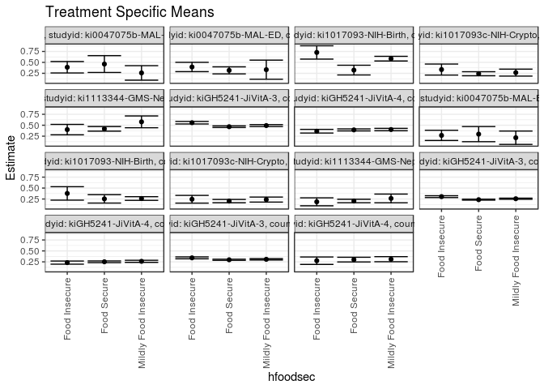

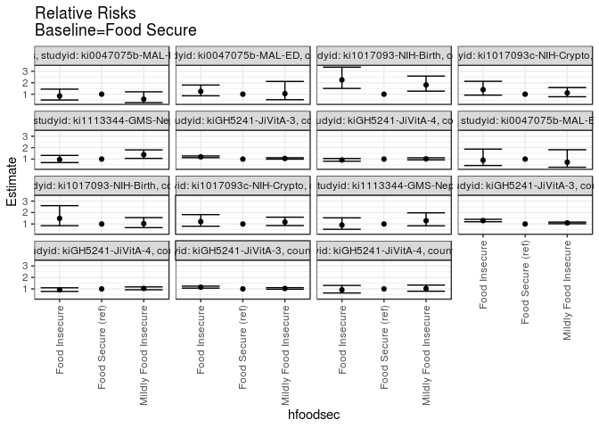

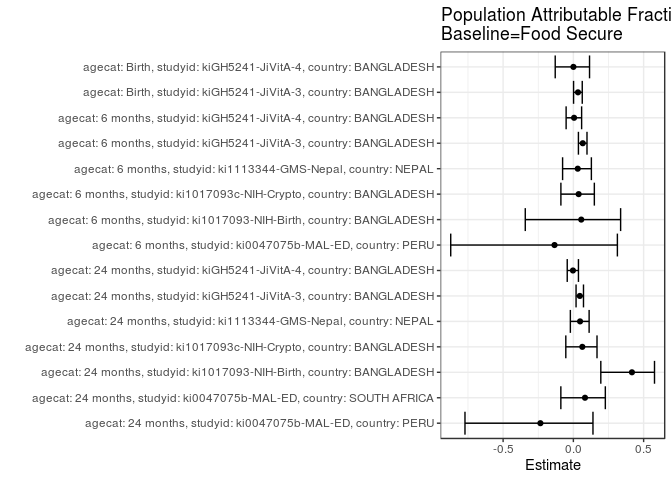

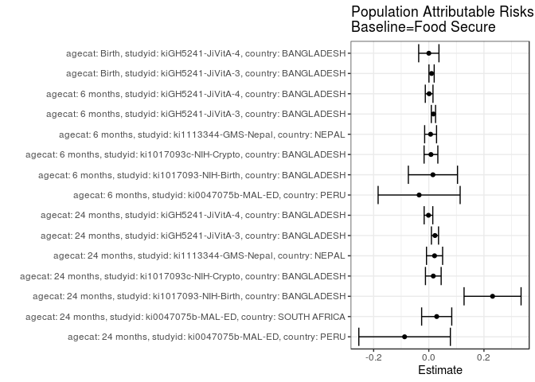

## Results Table

### Parameter: TSM

| agecat | studyid | country | intervention_level | baseline_level | estimate | ci_lower | ci_upper |
| --- | --- | --- | --- | --- | --- | --- | --- |
| Birth | kiGH5241-JiVitA-3 | BANGLADESH | Food Secure | NA | 0.2971876 | 0.2843159 | 0.3100593 |
| Birth | kiGH5241-JiVitA-3 | BANGLADESH | Mildly Food Insecure | NA | 0.3079152 | 0.2923750 | 0.3234554 |
| Birth | kiGH5241-JiVitA-3 | BANGLADESH | Food Insecure | NA | 0.3414696 | 0.3195074 | 0.3634317 |
| Birth | kiGH5241-JiVitA-4 | BANGLADESH | Food Secure | NA | 0.3014678 | 0.2478295 | 0.3551060 |
| Birth | kiGH5241-JiVitA-4 | BANGLADESH | Mildly Food Insecure | NA | 0.3106894 | 0.2525095 | 0.3688693 |
| Birth | kiGH5241-JiVitA-4 | BANGLADESH | Food Insecure | NA | 0.2760074 | 0.1910736 | 0.3609411 |
| 6 months | ki0047075b-MAL-ED | PERU | Food Secure | NA | 0.2962963 | 0.1232791 | 0.4693135 |
| 6 months | ki0047075b-MAL-ED | PERU | Mildly Food Insecure | NA | 0.2142857 | 0.0616124 | 0.3669590 |
| 6 months | ki0047075b-MAL-ED | PERU | Food Insecure | NA | 0.2678571 | 0.1513457 | 0.3843686 |
| 6 months | ki1017093-NIH-Birth | BANGLADESH | Food Secure | NA | 0.2531130 | 0.1568839 | 0.3493422 |
| 6 months | ki1017093-NIH-Birth | BANGLADESH | Mildly Food Insecure | NA | 0.2608973 | 0.2186679 | 0.3031267 |
| 6 months | ki1017093-NIH-Birth | BANGLADESH | Food Insecure | NA | 0.3773679 | 0.2233968 | 0.5313391 |
| 6 months | ki1017093c-NIH-Crypto | BANGLADESH | Food Secure | NA | 0.2019116 | 0.1639751 | 0.2398481 |
| 6 months | ki1017093c-NIH-Crypto | BANGLADESH | Mildly Food Insecure | NA | 0.2366325 | 0.1792776 | 0.2939874 |
| 6 months | ki1017093c-NIH-Crypto | BANGLADESH | Food Insecure | NA | 0.2444107 | 0.1562310 | 0.3325904 |
| 6 months | ki1113344-GMS-Nepal | NEPAL | Food Secure | NA | 0.2044474 | 0.1645434 | 0.2443514 |
| 6 months | ki1113344-GMS-Nepal | NEPAL | Mildly Food Insecure | NA | 0.2633310 | 0.1637120 | 0.3629499 |
| 6 months | ki1113344-GMS-Nepal | NEPAL | Food Insecure | NA | 0.1856289 | 0.0947076 | 0.2765501 |
| 6 months | kiGH5241-JiVitA-3 | BANGLADESH | Food Secure | NA | 0.2346100 | 0.2239026 | 0.2453174 |
| 6 months | kiGH5241-JiVitA-3 | BANGLADESH | Mildly Food Insecure | NA | 0.2560263 | 0.2431888 | 0.2688639 |
| 6 months | kiGH5241-JiVitA-3 | BANGLADESH | Food Insecure | NA | 0.3044354 | 0.2834801 | 0.3253907 |
| 6 months | kiGH5241-JiVitA-4 | BANGLADESH | Food Secure | NA | 0.2513738 | 0.2315078 | 0.2712398 |
| 6 months | kiGH5241-JiVitA-4 | BANGLADESH | Mildly Food Insecure | NA | 0.2616781 | 0.2380307 | 0.2853255 |
| 6 months | kiGH5241-JiVitA-4 | BANGLADESH | Food Insecure | NA | 0.2322395 | 0.1963677 | 0.2681113 |
| 24 months | ki0047075b-MAL-ED | PERU | Food Secure | NA | 0.4615385 | 0.2690159 | 0.6540610 |
| 24 months | ki0047075b-MAL-ED | PERU | Mildly Food Insecure | NA | 0.2592593 | 0.0931838 | 0.4253347 |
| 24 months | ki0047075b-MAL-ED | PERU | Food Insecure | NA | 0.3888889 | 0.2582528 | 0.5195249 |
| 24 months | ki0047075b-MAL-ED | SOUTH AFRICA | Food Secure | NA | 0.3178295 | 0.2373006 | 0.3983583 |
| 24 months | ki0047075b-MAL-ED | SOUTH AFRICA | Mildly Food Insecure | NA | 0.3333333 | 0.1150804 | 0.5515863 |
| 24 months | ki0047075b-MAL-ED | SOUTH AFRICA | Food Insecure | NA | 0.3950617 | 0.2883657 | 0.5017577 |
| 24 months | ki1017093-NIH-Birth | BANGLADESH | Food Secure | NA | 0.3235294 | 0.2122072 | 0.4348516 |
| 24 months | ki1017093-NIH-Birth | BANGLADESH | Mildly Food Insecure | NA | 0.5853659 | 0.5319876 | 0.6387441 |
| 24 months | ki1017093-NIH-Birth | BANGLADESH | Food Insecure | NA | 0.7272727 | 0.5751441 | 0.8794013 |
| 24 months | ki1017093c-NIH-Crypto | BANGLADESH | Food Secure | NA | 0.2404348 | 0.1943489 | 0.2865207 |
| 24 months | ki1017093c-NIH-Crypto | BANGLADESH | Mildly Food Insecure | NA | 0.2658936 | 0.1862249 | 0.3455623 |
| 24 months | ki1017093c-NIH-Crypto | BANGLADESH | Food Insecure | NA | 0.3359324 | 0.2101894 | 0.4616754 |
| 24 months | ki1113344-GMS-Nepal | NEPAL | Food Secure | NA | 0.4176127 | 0.3651517 | 0.4700737 |
| 24 months | ki1113344-GMS-Nepal | NEPAL | Mildly Food Insecure | NA | 0.5774876 | 0.4427211 | 0.7122541 |
| 24 months | ki1113344-GMS-Nepal | NEPAL | Food Insecure | NA | 0.4001582 | 0.2811797 | 0.5191368 |
| 24 months | kiGH5241-JiVitA-3 | BANGLADESH | Food Secure | NA | 0.4662275 | 0.4475019 | 0.4849532 |
| 24 months | kiGH5241-JiVitA-3 | BANGLADESH | Mildly Food Insecure | NA | 0.4918825 | 0.4696107 | 0.5141543 |
| 24 months | kiGH5241-JiVitA-3 | BANGLADESH | Food Insecure | NA | 0.5579633 | 0.5289053 | 0.5870212 |
| 24 months | kiGH5241-JiVitA-4 | BANGLADESH | Food Secure | NA | 0.3934843 | 0.3701617 | 0.4168068 |
| 24 months | kiGH5241-JiVitA-4 | BANGLADESH | Mildly Food Insecure | NA | 0.4011168 | 0.3739326 | 0.4283010 |
| 24 months | kiGH5241-JiVitA-4 | BANGLADESH | Food Insecure | NA | 0.3630347 | 0.3208857 | 0.4051836 |

### Parameter: E(Y)

| agecat | studyid | country | intervention_level | baseline_level | estimate | ci_lower | ci_upper |
| --- | --- | --- | --- | --- | --- | --- | --- |
| Birth | kiGH5241-JiVitA-3 | BANGLADESH | NA | NA | 0.3072590 | 0.2982359 | 0.3162822 |
| Birth | kiGH5241-JiVitA-4 | BANGLADESH | NA | NA | 0.3015873 | 0.2659035 | 0.3372711 |
| 6 months | ki0047075b-MAL-ED | PERU | NA | NA | 0.2612613 | 0.1791629 | 0.3433597 |
| 6 months | ki1017093-NIH-Birth | BANGLADESH | NA | NA | 0.2681564 | 0.2306532 | 0.3056597 |
| 6 months | ki1017093c-NIH-Crypto | BANGLADESH | NA | NA | 0.2097902 | 0.1799252 | 0.2396552 |
| 6 months | ki1113344-GMS-Nepal | NEPAL | NA | NA | 0.2110092 | 0.1767217 | 0.2452966 |
| 6 months | kiGH5241-JiVitA-3 | BANGLADESH | NA | NA | 0.2514442 | 0.2432971 | 0.2595914 |
| 6 months | kiGH5241-JiVitA-4 | BANGLADESH | NA | NA | 0.2526601 | 0.2384064 | 0.2669139 |
| 24 months | ki0047075b-MAL-ED | PERU | NA | NA | 0.3738318 | 0.2817277 | 0.4659358 |
| 24 months | ki0047075b-MAL-ED | SOUTH AFRICA | NA | NA | 0.3464912 | 0.2845889 | 0.4083936 |
| 24 months | ki1017093-NIH-Birth | BANGLADESH | NA | NA | 0.5547786 | 0.5076945 | 0.6018626 |
| 24 months | ki1017093c-NIH-Crypto | BANGLADESH | NA | NA | 0.2568093 | 0.2190047 | 0.2946140 |
| 24 months | ki1113344-GMS-Nepal | NEPAL | NA | NA | 0.4385246 | 0.3944543 | 0.4825949 |
| 24 months | kiGH5241-JiVitA-3 | BANGLADESH | NA | NA | 0.4886779 | 0.4752340 | 0.5021218 |
| 24 months | kiGH5241-JiVitA-4 | BANGLADESH | NA | NA | 0.3923191 | 0.3753084 | 0.4093298 |

### Parameter: RR

| agecat | studyid | country | intervention_level | baseline_level | estimate | ci_lower | ci_upper |
| --- | --- | --- | --- | --- | --- | --- | --- |
| Birth | kiGH5241-JiVitA-3 | BANGLADESH | Food Secure | Food Secure | 1.0000000 | 1.0000000 | 1.000000 |
| Birth | kiGH5241-JiVitA-3 | BANGLADESH | Mildly Food Insecure | Food Secure | 1.0360972 | 0.9711894 | 1.105343 |
| Birth | kiGH5241-JiVitA-3 | BANGLADESH | Food Insecure | Food Secure | 1.1490036 | 1.0634658 | 1.241421 |
| Birth | kiGH5241-JiVitA-4 | BANGLADESH | Food Secure | Food Secure | 1.0000000 | 1.0000000 | 1.000000 |
| Birth | kiGH5241-JiVitA-4 | BANGLADESH | Mildly Food Insecure | Food Secure | 1.0305891 | 0.7964596 | 1.333544 |
| Birth | kiGH5241-JiVitA-4 | BANGLADESH | Food Insecure | Food Secure | 0.9155451 | 0.6428322 | 1.303953 |
| 6 months | ki0047075b-MAL-ED | PERU | Food Secure | Food Secure | 1.0000000 | 1.0000000 | 1.000000 |
| 6 months | ki0047075b-MAL-ED | PERU | Mildly Food Insecure | Food Secure | 0.7232143 | 0.2878706 | 1.816924 |
| 6 months | ki0047075b-MAL-ED | PERU | Food Insecure | Food Secure | 0.9040179 | 0.4364671 | 1.872417 |
| 6 months | ki1017093-NIH-Birth | BANGLADESH | Food Secure | Food Secure | 1.0000000 | 1.0000000 | 1.000000 |
| 6 months | ki1017093-NIH-Birth | BANGLADESH | Mildly Food Insecure | Food Secure | 1.0307541 | 0.6818124 | 1.558279 |
| 6 months | ki1017093-NIH-Birth | BANGLADESH | Food Insecure | Food Secure | 1.4909067 | 0.8536360 | 2.603924 |
| 6 months | ki1017093c-NIH-Crypto | BANGLADESH | Food Secure | Food Secure | 1.0000000 | 1.0000000 | 1.000000 |
| 6 months | ki1017093c-NIH-Crypto | BANGLADESH | Mildly Food Insecure | Food Secure | 1.1719611 | 0.8616372 | 1.594050 |
| 6 months | ki1017093c-NIH-Crypto | BANGLADESH | Food Insecure | Food Secure | 1.2104837 | 0.8062902 | 1.817300 |
| 6 months | ki1113344-GMS-Nepal | NEPAL | Food Secure | Food Secure | 1.0000000 | 1.0000000 | 1.000000 |
| 6 months | ki1113344-GMS-Nepal | NEPAL | Mildly Food Insecure | Food Secure | 1.2880131 | 0.8410196 | 1.972579 |
| 6 months | ki1113344-GMS-Nepal | NEPAL | Food Insecure | Food Secure | 0.9079541 | 0.5360307 | 1.537935 |
| 6 months | kiGH5241-JiVitA-3 | BANGLADESH | Food Secure | Food Secure | 1.0000000 | 1.0000000 | 1.000000 |
| 6 months | kiGH5241-JiVitA-3 | BANGLADESH | Mildly Food Insecure | Food Secure | 1.0912848 | 1.0249949 | 1.161862 |
| 6 months | kiGH5241-JiVitA-3 | BANGLADESH | Food Insecure | Food Secure | 1.2976231 | 1.1963688 | 1.407447 |
| 6 months | kiGH5241-JiVitA-4 | BANGLADESH | Food Secure | Food Secure | 1.0000000 | 1.0000000 | 1.000000 |
| 6 months | kiGH5241-JiVitA-4 | BANGLADESH | Mildly Food Insecure | Food Secure | 1.0409919 | 0.9228054 | 1.174315 |
| 6 months | kiGH5241-JiVitA-4 | BANGLADESH | Food Insecure | Food Secure | 0.9238813 | 0.7779307 | 1.097214 |
| 24 months | ki0047075b-MAL-ED | PERU | Food Secure | Food Secure | 1.0000000 | 1.0000000 | 1.000000 |
| 24 months | ki0047075b-MAL-ED | PERU | Mildly Food Insecure | Food Secure | 0.5617284 | 0.2615430 | 1.206451 |
| 24 months | ki0047075b-MAL-ED | PERU | Food Insecure | Food Secure | 0.8425926 | 0.4931961 | 1.439513 |
| 24 months | ki0047075b-MAL-ED | SOUTH AFRICA | Food Secure | Food Secure | 1.0000000 | 1.0000000 | 1.000000 |
| 24 months | ki0047075b-MAL-ED | SOUTH AFRICA | Mildly Food Insecure | Food Secure | 1.0487805 | 0.5197306 | 2.116366 |
| 24 months | ki0047075b-MAL-ED | SOUTH AFRICA | Food Insecure | Food Secure | 1.2429991 | 0.8583073 | 1.800109 |
| 24 months | ki1017093-NIH-Birth | BANGLADESH | Food Secure | Food Secure | 1.0000000 | 1.0000000 | 1.000000 |
| 24 months | ki1017093-NIH-Birth | BANGLADESH | Mildly Food Insecure | Food Secure | 1.8093126 | 1.2674186 | 2.582897 |
| 24 months | ki1017093-NIH-Birth | BANGLADESH | Food Insecure | Food Secure | 2.2479339 | 1.5028032 | 3.362521 |
| 24 months | ki1017093c-NIH-Crypto | BANGLADESH | Food Secure | Food Secure | 1.0000000 | 1.0000000 | 1.000000 |
| 24 months | ki1017093c-NIH-Crypto | BANGLADESH | Mildly Food Insecure | Food Secure | 1.1058866 | 0.7749495 | 1.578148 |
| 24 months | ki1017093c-NIH-Crypto | BANGLADESH | Food Insecure | Food Secure | 1.3971873 | 0.9172942 | 2.128142 |
| 24 months | ki1113344-GMS-Nepal | NEPAL | Food Secure | Food Secure | 1.0000000 | 1.0000000 | 1.000000 |
| 24 months | ki1113344-GMS-Nepal | NEPAL | Mildly Food Insecure | Food Secure | 1.3828306 | 1.0611478 | 1.802030 |
| 24 months | ki1113344-GMS-Nepal | NEPAL | Food Insecure | Food Secure | 0.9582042 | 0.6943377 | 1.322347 |
| 24 months | kiGH5241-JiVitA-3 | BANGLADESH | Food Secure | Food Secure | 1.0000000 | 1.0000000 | 1.000000 |
| 24 months | kiGH5241-JiVitA-3 | BANGLADESH | Mildly Food Insecure | Food Secure | 1.0550267 | 0.9969992 | 1.116432 |
| 24 months | kiGH5241-JiVitA-3 | BANGLADESH | Food Insecure | Food Secure | 1.1967617 | 1.1243479 | 1.273839 |
| 24 months | kiGH5241-JiVitA-4 | BANGLADESH | Food Secure | Food Secure | 1.0000000 | 1.0000000 | 1.000000 |
| 24 months | kiGH5241-JiVitA-4 | BANGLADESH | Mildly Food Insecure | Food Secure | 1.0193972 | 0.9339856 | 1.112620 |
| 24 months | kiGH5241-JiVitA-4 | BANGLADESH | Food Insecure | Food Secure | 0.9226154 | 0.8113775 | 1.049104 |

### Parameter: PAR

| agecat | studyid | country | intervention_level | baseline_level | estimate | ci_lower | ci_upper |
| --- | --- | --- | --- | --- | --- | --- | --- |
| Birth | kiGH5241-JiVitA-3 | BANGLADESH | Food Secure | NA | 0.0100715 | 0.0005674 | 0.0195755 |
| Birth | kiGH5241-JiVitA-4 | BANGLADESH | Food Secure | NA | 0.0001195 | -0.0366174 | 0.0368565 |
| 6 months | ki0047075b-MAL-ED | PERU | Food Secure | NA | -0.0350350 | -0.1837366 | 0.1136665 |
| 6 months | ki1017093-NIH-Birth | BANGLADESH | Food Secure | NA | 0.0150434 | -0.0740784 | 0.1041652 |
| 6 months | ki1017093c-NIH-Crypto | BANGLADESH | Food Secure | NA | 0.0078786 | -0.0170531 | 0.0328104 |
| 6 months | ki1113344-GMS-Nepal | NEPAL | Food Secure | NA | 0.0065618 | -0.0150134 | 0.0281370 |
| 6 months | kiGH5241-JiVitA-3 | BANGLADESH | Food Secure | NA | 0.0168342 | 0.0091395 | 0.0245289 |
| 6 months | kiGH5241-JiVitA-4 | BANGLADESH | Food Secure | NA | 0.0012863 | -0.0126405 | 0.0152131 |
| 24 months | ki0047075b-MAL-ED | PERU | Food Secure | NA | -0.0877067 | -0.2536441 | 0.0782307 |
| 24 months | ki0047075b-MAL-ED | SOUTH AFRICA | Food Secure | NA | 0.0286618 | -0.0259150 | 0.0832385 |
| 24 months | ki1017093-NIH-Birth | BANGLADESH | Food Secure | NA | 0.2312491 | 0.1279008 | 0.3345975 |
| 24 months | ki1017093c-NIH-Crypto | BANGLADESH | Food Secure | NA | 0.0163746 | -0.0120943 | 0.0448434 |
| 24 months | ki1113344-GMS-Nepal | NEPAL | Food Secure | NA | 0.0209119 | -0.0082979 | 0.0501217 |
| 24 months | kiGH5241-JiVitA-3 | BANGLADESH | Food Secure | NA | 0.0224503 | 0.0095603 | 0.0353403 |
| 24 months | kiGH5241-JiVitA-4 | BANGLADESH | Food Secure | NA | -0.0011652 | -0.0168251 | 0.0144947 |

### Parameter: PAF

| agecat | studyid | country | intervention_level | baseline_level | estimate | ci_lower | ci_upper |
| --- | --- | --- | --- | --- | --- | --- | --- |
| Birth | kiGH5241-JiVitA-3 | BANGLADESH | Food Secure | NA | 0.0327784 | 0.0013665 | 0.0632023 |
| Birth | kiGH5241-JiVitA-4 | BANGLADESH | Food Secure | NA | 0.0003963 | -0.1291538 | 0.1150828 |
| 6 months | ki0047075b-MAL-ED | PERU | Food Secure | NA | -0.1340996 | -0.8728000 | 0.3132305 |
| 6 months | ki1017093-NIH-Birth | BANGLADESH | Food Secure | NA | 0.0560993 | -0.3422615 | 0.3362333 |
| 6 months | ki1017093c-NIH-Crypto | BANGLADESH | Food Secure | NA | 0.0375548 | -0.0887693 | 0.1492222 |
| 6 months | ki1113344-GMS-Nepal | NEPAL | Food Secure | NA | 0.0310970 | -0.0766942 | 0.1280969 |
| 6 months | kiGH5241-JiVitA-3 | BANGLADESH | Food Secure | NA | 0.0669500 | 0.0359570 | 0.0969466 |
| 6 months | kiGH5241-JiVitA-4 | BANGLADESH | Food Secure | NA | 0.0050912 | -0.0515839 | 0.0587118 |
| 24 months | ki0047075b-MAL-ED | PERU | Food Secure | NA | -0.2346154 | -0.7713345 | 0.1394764 |
| 24 months | ki0047075b-MAL-ED | SOUTH AFRICA | Food Secure | NA | 0.0827200 | -0.0891025 | 0.2274349 |
| 24 months | ki1017093-NIH-Birth | BANGLADESH | Food Secure | NA | 0.4168314 | 0.1952617 | 0.5773961 |
| 24 months | ki1017093c-NIH-Crypto | BANGLADESH | Food Secure | NA | 0.0637616 | -0.0538033 | 0.1682106 |
| 24 months | ki1113344-GMS-Nepal | NEPAL | Food Secure | NA | 0.0476870 | -0.0214056 | 0.1121058 |
| 24 months | kiGH5241-JiVitA-3 | BANGLADESH | Food Secure | NA | 0.0459410 | 0.0191505 | 0.0719997 |
| 24 months | kiGH5241-JiVitA-4 | BANGLADESH | Food Secure | NA | -0.0029700 | -0.0436890 | 0.0361604 |